# Quando usar modelo misto (e quando não)

Critérios práticos para a escolha do método

Author

Marcelo Silva

Published

October 8, 2026

## 1 Use modelo misto quando

- Houver medidas repetidas no mesmo sujeito ou unidade.
- Os dados tiverem estrutura hierárquica (alunos em turmas, pacientes em hospitais, réplicas biológicas).
- Os grupos que você coletou forem apenas uma amostra de uma população maior de grupos, e você quiser generalizar para ela (e não só estimar estes que amostrou).

## 2 Não use modelo misto quando

- Cada observação for independente: a regressão comum (`lm`) basta.
- Os grupos forem poucos e você quiser estimar cada um individualmente: use efeito fixo para categoria.

## 3 Exemplo

Se eu comparar a regressão comum com o modelo misto, vai ficar claro quando a escolha importa.

```r
# Compare lm e lmer em dados com agrupamento claro
library(tidyverse)
library(lme4)
library(lmerTest)
library(nlme)
data(sleepstudy)
m_lm  <- lm(Reaction ~ Days, data = sleepstudy)
m_misto <- lmer(Reaction ~ Days + (1 | Subject), data = sleepstudy)
summary(m_lm)
```

```
Call:
lm(formula = Reaction ~ Days, data = sleepstudy)

Residuals:
     Min       1Q   Median       3Q      Max
-110.848  -27.483    1.546   26.142  139.953

Coefficients:
            Estimate Std. Error t value Pr(>|t|)
(Intercept)  251.405      6.610  38.033  < 2e-16 ***
Days          10.467      1.238   8.454 9.89e-15 ***
---
Signif. codes:  0 '***' 0.001 '**' 0.01 '*' 0.05 '.' 0.1 ' ' 1

Residual standard error: 47.71 on 178 degrees of freedom
Multiple R-squared:  0.2865,    Adjusted R-squared:  0.2825
F-statistic: 71.46 on 1 and 178 DF,  p-value: 9.894e-15
```

```r
summary(m_misto)
```

```
Linear mixed model fit by REML. t-tests use Satterthwaite's method [
lmerModLmerTest]
Formula: Reaction ~ Days + (1 | Subject)
   Data: sleepstudy

REML criterion at convergence: 1786.5

Scaled residuals:
    Min      1Q  Median      3Q     Max
-3.2257 -0.5529  0.0109  0.5188  4.2506

Random effects:
 Groups   Name        Variance Std.Dev.
 Subject  (Intercept) 1378.2   37.12
 Residual              960.5   30.99
Number of obs: 180, groups:  Subject, 18

Fixed effects:
            Estimate Std. Error       df t value Pr(>|t|)
(Intercept) 251.4051     9.7467  22.8102   25.79   <2e-16 ***
Days         10.4673     0.8042 161.0000   13.02   <2e-16 ***
---
Signif. codes:  0 '***' 0.001 '**' 0.01 '*' 0.05 '.' 0.1 ' ' 1

Correlation of Fixed Effects:
     (Intr)
Days -0.371
```

```r
cat("\nEP de Days (lm): ", round(summary(m_lm)$coef["Days","Std. Error"],3),
    "\nEP de Days (lmer):", round(summary(m_misto)$coef["Days","Std. Error"],3), "\n")
```

```
EP de Days (lm):  1.238
EP de Days (lmer): 0.804
```

O erro-padrão do lm e do lmer sao diferentes.

Quando você ajusta `lm(Reaction ~ Days)` sem levar em conta o agrupamento:

- O modelo trata todos os 180 dados como independentes.
- A variância residual tem que explicar tudo: tanto a variação within (dentro do sujeito) quanto a between (entre os sujeitos).

Quando você ajusta `lmer(Reaction ~ Days + (1 | Subject))`:

- A variância é particionada: entre-sujeito (random intercept) vs. dentro-sujeito (residual)
- O efeito fixo de `Days` é estimado a partir da variação dentro de cada sujeito (o sinal que importa), não do ruído entre sujeitos
- Resultado: SE menor, estimativa mais precisa

E se eu fizesse a seguinte pergunta? O tempo de reação de cada sujeito varia ao longo das visitas?

```r
m_misto_slope_aleatorio <- lmer(Reaction ~ Days + (1 + Days | Subject), data = sleepstudy)
summary(m_misto_slope_aleatorio)
```

```
Linear mixed model fit by REML. t-tests use Satterthwaite's method [
lmerModLmerTest]
Formula: Reaction ~ Days + (1 + Days | Subject)
   Data: sleepstudy

REML criterion at convergence: 1743.6

Scaled residuals:
    Min      1Q  Median      3Q     Max
-3.9536 -0.4634  0.0231  0.4634  5.1793

Random effects:
 Groups   Name        Variance Std.Dev. Corr
 Subject  (Intercept) 612.10   24.741
          Days         35.07    5.922   0.07
 Residual             654.94   25.592
Number of obs: 180, groups:  Subject, 18

Fixed effects:
            Estimate Std. Error      df t value Pr(>|t|)
(Intercept)  251.405      6.825  17.000  36.838  < 2e-16 ***
Days          10.467      1.546  17.000   6.771 3.26e-06 ***
---
Signif. codes:  0 '***' 0.001 '**' 0.01 '*' 0.05 '.' 0.1 ' ' 1

Correlation of Fixed Effects:
     (Intr)
Days -0.138
```

## 4 Checklist rápida

1. As medidas são independentes? Se sim, `lm`. Se não, misto.
2. Quero estimar cada grupo ou só descrever a variação? Estimar = fixo; descrever = aleatório.

## 5 Caso estudo esferóides

```r
esferoides <- readxl::read_xlsx("Dados_231_replicasbiologicas.xlsx")

esferoides <- esferoides %>%
  mutate(
  Tempo = factor(Tempo, levels = c('0h', '72h')),
  Replica = factor(Replica),
  Grupo = factor(Grupo, levels = c("CT_DMSO", "Carbo","Doxo",  "Ert+Akt","Paclitaxel","TriplaCarbo","TriplaDoxo","TriplaPaclitaxel"))
) %>%
  group_by(Grupo, Tempo) %>%
  mutate(
    indice = row_number()
  ) %>%
  ungroup() %>%
  mutate(
    ID = interaction(Grupo, indice, Replica, drop = T),
    logArea = log(Area)
  )
```

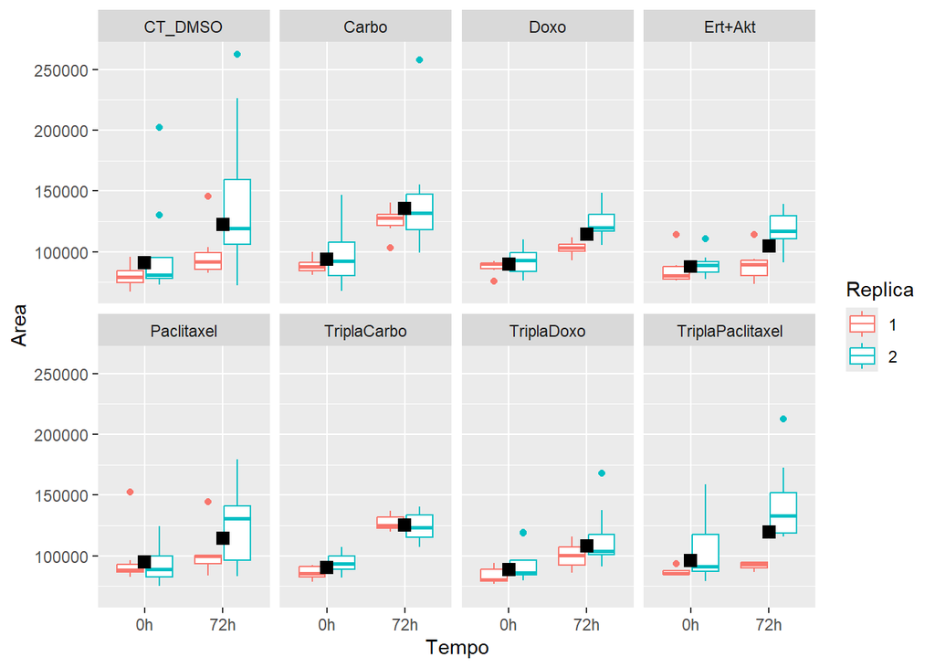

```r
esferoides %>%
  ggplot(aes(x = Tempo, y = Area, colour = Replica)) +
  geom_boxplot() +
  stat_summary(fun = mean, geom = 'point', shape = 15, size = 3, colour = 'black')+
  facet_wrap(~ Grupo, ncol = 4 )
```

```r
largo <- esferoides %>%
  select(Grupo, Replica, indice, Tempo, logArea) %>%
  pivot_wider(
    names_from = Tempo,
    values_from = logArea
  ) %>%
  rename(
    log_0h = '0h',
    log_72h = '72h'
  ) %>%
  group_by(Grupo) %>%
  mutate(
    dif = log_72h - log_0h
  ) %>%
  ungroup() %>%
  mutate(
    indice = interaction(Replica, Grupo)
  )
```

Para conferir o índice acima, se deu certo, faça utilize a função count abaixo

```r
largo %>% count(indice)
```

| indice | n |
| --- | --- |
| 1.CT_DMSO | 7 |
| 2.CT_DMSO | 8 |
| 1.Carbo | 7 |
| 2.Carbo | 8 |
| 1.Doxo | 7 |
| 2.Doxo | 8 |
| 1.Ert+Akt | 7 |
| 2.Ert+Akt | 8 |
| 1.Paclitaxel | 7 |
| 2.Paclitaxel | 8 |

[output cut: 6 more lines]

Observe o resultado da funçao acima mostra que o indice CT_DMSO repete 7 vezes na replica biológica 1, o que deve bater com o número de replicatas técnicas.

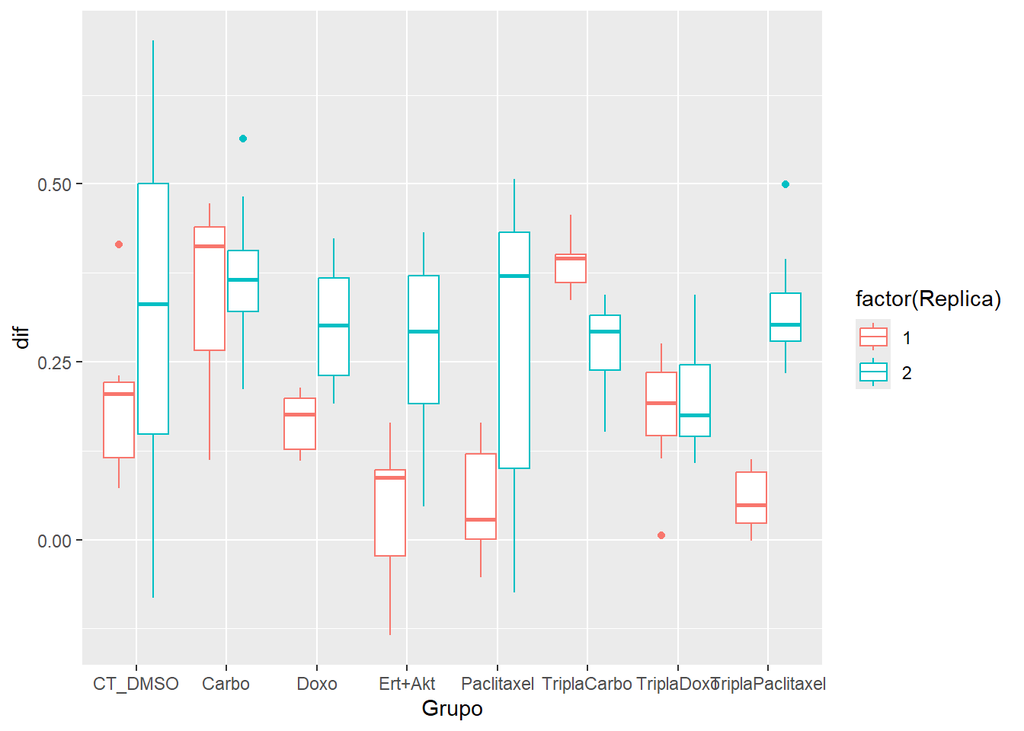

```r
largo %>%
  ggplot(aes(x = Grupo, y = dif, colour = factor(Replica)))+
  geom_boxplot()
```

### 5.1 Vamos analisar a qualidade do experimento utilizando o coeficiente de variaçao

```r
largo %>%
  group_by(Replica, Grupo) %>%
  summarise(
    n = n(),
    coef_var = sd(dif)*100/mean(dif)
  )
```

| Replica | Grupo | n | coef_var |
| --- | --- | --- | --- |
| 1 | CT_DMSO | 7 | 59.57058 |
| 1 | Carbo | 7 | 38.63142 |
| 1 | Doxo | 7 | 25.73140 |
| 1 | Ert+Akt | 7 | 270.72913 |
| 1 | Paclitaxel | 7 | 147.63552 |
| 1 | TriplaCarbo | 7 | 10.17381 |
| 1 | TriplaDoxo | 7 | 51.74974 |
| 1 | TriplaPaclitaxel | 7 | 79.52127 |
| 2 | CT_DMSO | 8 | 80.19836 |
| 2 | Carbo | 8 | 29.23917 |

[output cut: 6 more lines]

### 5.2 Realizando o modelo

```r
m_lme <- lme(dif ~ Grupo, random = ~1 | indice, weights = varIdent(form = ~1 | Grupo), data = largo, method = "REML")
summary(m_lme)
```

```
Linear mixed-effects model fit by REML
  Data: largo
        AIC       BIC   logLik
  -118.5993 -72.38486 76.29967

Random effects:
 Formula: ~1 | indice
        (Intercept)  Residual
StdDev:   0.1121521 0.2086556

Variance function:
 Structure: Different standard deviations per stratum
 Formula: ~1 | Grupo
 Parameter estimates:
         CT_DMSO            Carbo             Doxo          Ert+Akt
       1.0000000        0.5758866        0.3451081        0.5694473
      Paclitaxel      TriplaCarbo       TriplaDoxo TriplaPaclitaxel
       0.8432732        0.2601721        0.4032754        0.3317383
Fixed effects:  dif ~ Grupo
                            Value  Std.Error  DF    t-value p-value
(Intercept)            0.26432055 0.09591859 104  2.7556759  0.0069
GrupoCarbo             0.09469474 0.12827992   8  0.7381883  0.4815
GrupoDoxo             -0.03073829 0.12584342   8 -0.2442582  0.8132
GrupoErt+Akt          -0.10746728 0.12819618   8 -0.8383033  0.4262
GrupoPaclitaxel       -0.09618415 0.13251540   8 -0.7258337  0.4886
GrupoTriplaCarbo       0.06503254 0.12524671   8  0.5192355  0.6177
GrupoTriplaDoxo       -0.07689099 0.12634640   8 -0.6085729  0.5597
GrupoTriplaPaclitaxel -0.07224689 0.12573860   8 -0.5745800  0.5814
 Correlation:
                      (Intr) GrpCrb GrupDx GrpE+A GrpPcl GrpTrC GrpTrD
GrupoCarbo            -0.748
GrupoDoxo             -0.762  0.570
GrupoErt+Akt          -0.748  0.559  0.570
GrupoPaclitaxel       -0.724  0.541  0.552  0.542
GrupoTriplaCarbo      -0.766  0.573  0.584  0.573  0.554
GrupoTriplaDoxo       -0.759  0.568  0.579  0.568  0.550  0.581
GrupoTriplaPaclitaxel -0.763  0.570  0.581  0.571  0.552  0.584  0.579

Standardized Within-Group Residuals:
        Min          Q1         Med          Q3         Max
-2.22580454 -0.68543654  0.06466826  0.65149605  2.58775903

Number of Observations: 120
Number of Groups: 16
```

**NoteUMA OBSERVAÇÃO IMPORTANTE**

Se quiser utilizar Replica como fator fixo, mantendo a variação diferente entre grupos, pode-se utilizar o gls com a seguinte sintaxe

m_gls <- gls(dif ~ Grupo + Replica, weights = varIdent(form = ~1 | Grupo), data = largo, method = “REML”) summary(m_gls)

### 5.3 Obtendo as médias marginais

```r
library(emmeans)
medias_marginais <- emmeans(m_lme, specs = ~ Grupo)
medias_marginais
```

```
 Grupo            emmean     SE df lower.CL upper.CL
 CT_DMSO           0.264 0.0959 15  0.05987    0.469
 Carbo             0.359 0.0852  8  0.16259    0.555
 Doxo              0.234 0.0815  8  0.04573    0.421
 Ert+Akt           0.157 0.0851  8 -0.03928    0.353
 Paclitaxel        0.168 0.0914  8 -0.04271    0.379
 TriplaCarbo       0.329 0.0805  8  0.14363    0.515
 TriplaDoxo        0.187 0.0822  8 -0.00221    0.377
 TriplaPaclitaxel  0.192 0.0813  8  0.00459    0.380

Degrees-of-freedom method: containment
Confidence level used: 0.95
```

### 5.4 Fazendo a comparação entre pares

```r
dunnet <- contrast(medias_marginais, method = "trt.vs.ctrl", ref = 1)
dunnet
```

```
 contrast                   estimate    SE df t.ratio p.value
 Carbo - CT_DMSO              0.0947 0.128  8   0.738  0.9137
 Doxo - CT_DMSO              -0.0307 0.126  8  -0.244  0.9971
 (Ert+Akt) - CT_DMSO         -0.1075 0.128  8  -0.838  0.8780
 Paclitaxel - CT_DMSO        -0.0962 0.133  8  -0.726  0.9177
 TriplaCarbo - CT_DMSO        0.0650 0.125  8   0.519  0.9689
 TriplaDoxo - CT_DMSO        -0.0769 0.126  8  -0.609  0.9502
 TriplaPaclitaxel - CT_DMSO  -0.0722 0.126  8  -0.575  0.9580

Degrees-of-freedom method: containment
P value adjustment: dunnettx method for 7 tests
```

```r
dunnet_ic <- confint(dunnet)
```

### 5.5 Como escolho pares para comparar

```r
# meus níveis "CT_DMSO"          "Carbo"            "Doxo"             "Ert+Akt"          "Paclitaxel"       "TriplaCarbo"      "TriplaDoxo"      "TriplaPaclitaxel"

pares_escolhidos <- contrast(medias_marginais, method = list(
  "Tripla Cargo - Carbo " = c(0, -1, 0, 0, 0, 1, 0, 0),
  "Tripla Doxo - doxo " = c(0, 0, -1, 0, 0, 0, 1, 0),
  "TriplaPaclitaxel - Paclitaxel " = c(0, 0, 0, 0, -1, 0, 0, 1)
), adjust = 'sidak') # ou holm

pares_escolhidos
```

```
 contrast                       estimate    SE df t.ratio p.value
 Tripla Cargo - Carbo            -0.0297 0.117  8  -0.253  0.9928
 Tripla Doxo - doxo              -0.0462 0.116  8  -0.399  0.9731
 TriplaPaclitaxel - Paclitaxel    0.0239 0.122  8   0.196  0.9966

Degrees-of-freedom method: containment
P value adjustment: sidak method for 3 tests
```